# Risk Factor Analysis

## Outcome Variable

**Outcome Variable:** haz

## Predictor Variables

**Intervention Variable:** nhh

**Adjustment Set:**

- arm
- W_mage
- meducyrs
- feducyrs
- hhwealth_quart
- W_mhtcm
- W_mwtkg
- W_mbmi
- W_nrooms
- cleanck
- impfloor
- impsan
- safeh20
- delta_W_mage
- delta_meducyrs
- delta_feducyrs
- delta_hhwealth_quart
- delta_W_mhtcm
- delta_W_mwtkg
- delta_W_mbmi
- delta_W_nrooms
- delta_cleanck
- delta_impfloor
- delta_impsan
- delta_safeh20

## Stratifying Variables

The analysis was stratified on these variable(s):

- agecat
- studyid
- country

## Data Summary

| agecat | studyid | country | nhh | n_cell | n |
| --- | --- | --- | --- | --- | --- |
| Birth | ki1000108-IRC | INDIA | 3 or less | 54 | 388 |
| Birth | ki1000108-IRC | INDIA | 4-5 | 150 | 388 |
| Birth | ki1000108-IRC | INDIA | 6-7 | 103 | 388 |
| Birth | ki1000108-IRC | INDIA | 8+ | 81 | 388 |
| Birth | ki1017093-NIH-Birth | BANGLADESH | 3 or less | 112 | 608 |
| Birth | ki1017093-NIH-Birth | BANGLADESH | 4-5 | 255 | 608 |
| Birth | ki1017093-NIH-Birth | BANGLADESH | 6-7 | 138 | 608 |
| Birth | ki1017093-NIH-Birth | BANGLADESH | 8+ | 103 | 608 |
| Birth | ki1017093b-PROVIDE | BANGLADESH | 3 or less | 104 | 539 |
| Birth | ki1017093b-PROVIDE | BANGLADESH | 4-5 | 251 | 539 |
| Birth | ki1017093b-PROVIDE | BANGLADESH | 6-7 | 116 | 539 |
| Birth | ki1017093b-PROVIDE | BANGLADESH | 8+ | 68 | 539 |
| Birth | ki1017093c-NIH-Crypto | BANGLADESH | 3 or less | 108 | 732 |
| Birth | ki1017093c-NIH-Crypto | BANGLADESH | 4-5 | 328 | 732 |
| Birth | ki1017093c-NIH-Crypto | BANGLADESH | 6-7 | 176 | 732 |
| Birth | ki1017093c-NIH-Crypto | BANGLADESH | 8+ | 120 | 732 |
| 6 months | ki1000108-IRC | INDIA | 3 or less | 58 | 407 |
| 6 months | ki1000108-IRC | INDIA | 4-5 | 158 | 407 |
| 6 months | ki1000108-IRC | INDIA | 6-7 | 106 | 407 |
| 6 months | ki1000108-IRC | INDIA | 8+ | 85 | 407 |
| 6 months | ki1000304b-SAS-FoodSuppl | INDIA | 3 or less | 33 | 380 |
| 6 months | ki1000304b-SAS-FoodSuppl | INDIA | 4-5 | 166 | 380 |
| 6 months | ki1000304b-SAS-FoodSuppl | INDIA | 6-7 | 115 | 380 |
| 6 months | ki1000304b-SAS-FoodSuppl | INDIA | 8+ | 66 | 380 |
| 6 months | ki1017093-NIH-Birth | BANGLADESH | 3 or less | 95 | 537 |
| 6 months | ki1017093-NIH-Birth | BANGLADESH | 4-5 | 227 | 537 |
| 6 months | ki1017093-NIH-Birth | BANGLADESH | 6-7 | 128 | 537 |
| 6 months | ki1017093-NIH-Birth | BANGLADESH | 8+ | 87 | 537 |
| 6 months | ki1017093b-PROVIDE | BANGLADESH | 3 or less | 105 | 604 |
| 6 months | ki1017093b-PROVIDE | BANGLADESH | 4-5 | 289 | 604 |
| 6 months | ki1017093b-PROVIDE | BANGLADESH | 6-7 | 130 | 604 |
| 6 months | ki1017093b-PROVIDE | BANGLADESH | 8+ | 80 | 604 |
| 6 months | ki1017093c-NIH-Crypto | BANGLADESH | 3 or less | 104 | 715 |
| 6 months | ki1017093c-NIH-Crypto | BANGLADESH | 4-5 | 326 | 715 |
| 6 months | ki1017093c-NIH-Crypto | BANGLADESH | 6-7 | 170 | 715 |
| 6 months | ki1017093c-NIH-Crypto | BANGLADESH | 8+ | 115 | 715 |
| 6 months | ki1148112-LCNI-5 | MALAWI | 3 or less | 224 | 816 |
| 6 months | ki1148112-LCNI-5 | MALAWI | 4-5 | 340 | 816 |
| 6 months | ki1148112-LCNI-5 | MALAWI | 6-7 | 182 | 816 |
| 6 months | ki1148112-LCNI-5 | MALAWI | 8+ | 70 | 816 |
| 24 months | ki1000108-IRC | INDIA | 3 or less | 58 | 409 |
| 24 months | ki1000108-IRC | INDIA | 4-5 | 158 | 409 |
| 24 months | ki1000108-IRC | INDIA | 6-7 | 107 | 409 |
| 24 months | ki1000108-IRC | INDIA | 8+ | 86 | 409 |
| 24 months | ki1017093-NIH-Birth | BANGLADESH | 3 or less | 75 | 429 |
| 24 months | ki1017093-NIH-Birth | BANGLADESH | 4-5 | 184 | 429 |
| 24 months | ki1017093-NIH-Birth | BANGLADESH | 6-7 | 100 | 429 |
| 24 months | ki1017093-NIH-Birth | BANGLADESH | 8+ | 70 | 429 |
| 24 months | ki1017093b-PROVIDE | BANGLADESH | 3 or less | 106 | 578 |
| 24 months | ki1017093b-PROVIDE | BANGLADESH | 4-5 | 273 | 578 |
| 24 months | ki1017093b-PROVIDE | BANGLADESH | 6-7 | 117 | 578 |
| 24 months | ki1017093b-PROVIDE | BANGLADESH | 8+ | 82 | 578 |
| 24 months | ki1017093c-NIH-Crypto | BANGLADESH | 3 or less | 69 | 514 |
| 24 months | ki1017093c-NIH-Crypto | BANGLADESH | 4-5 | 232 | 514 |
| 24 months | ki1017093c-NIH-Crypto | BANGLADESH | 6-7 | 130 | 514 |
| 24 months | ki1017093c-NIH-Crypto | BANGLADESH | 8+ | 83 | 514 |
| 24 months | ki1148112-LCNI-5 | MALAWI | 3 or less | 159 | 574 |
| 24 months | ki1148112-LCNI-5 | MALAWI | 4-5 | 237 | 574 |
| 24 months | ki1148112-LCNI-5 | MALAWI | 6-7 | 129 | 574 |
| 24 months | ki1148112-LCNI-5 | MALAWI | 8+ | 49 | 574 |

The following strata were considered:

- agecat: 24 months, studyid: ki1000108-IRC, country: INDIA
- agecat: 24 months, studyid: ki1017093-NIH-Birth, country: BANGLADESH
- agecat: 24 months, studyid: ki1017093b-PROVIDE, country: BANGLADESH
- agecat: 24 months, studyid: ki1017093c-NIH-Crypto, country: BANGLADESH
- agecat: 24 months, studyid: ki1148112-LCNI-5, country: MALAWI
- agecat: 6 months, studyid: ki1000108-IRC, country: INDIA
- agecat: 6 months, studyid: ki1000304b-SAS-FoodSuppl, country: INDIA
- agecat: 6 months, studyid: ki1017093-NIH-Birth, country: BANGLADESH
- agecat: 6 months, studyid: ki1017093b-PROVIDE, country: BANGLADESH
- agecat: 6 months, studyid: ki1017093c-NIH-Crypto, country: BANGLADESH
- agecat: 6 months, studyid: ki1148112-LCNI-5, country: MALAWI
- agecat: Birth, studyid: ki1000108-IRC, country: INDIA
- agecat: Birth, studyid: ki1017093-NIH-Birth, country: BANGLADESH
- agecat: Birth, studyid: ki1017093b-PROVIDE, country: BANGLADESH
- agecat: Birth, studyid: ki1017093c-NIH-Crypto, country: BANGLADESH

## Methods Detail

We’re interested in the causal parameters $E[Y_a]$ for all values of $a \in \mathcal{A}$. These parameters represent the mean outcome if, possibly contrary to fact, we intervened to set all units to have $A=a$. Under the randomization and positivity assumptions, these are identified by the statistical parameters $\psi_a=E_W[E_{Y|A,W}(Y|A=a,W)]$. In addition, we’re interested in the mean of $Y$, $E[Y]$ under no intervention (the observed mean). We will estimate these parameters by using SuperLearner to fit the relevant likelihood factors – $E_{Y|A,W}(Y|A=a,W)$ and $p(A=a|W)$, and then updating our likelihood fit using a joint TMLE.

For unadjusted analyses ($W=\{\}$), initial likelihoods were estimated using Lrnr_glm to estimate the simple $E(Y|A)$ and Lrnr_mean to estimate $p(A)$. For adjusted analyses, a small library containing Lrnr_glmnet, Lrnr_xgboost, and Lrnr_mean was used.

Having estimated these parameters, we will then use the delta method to estimate relative risks and attributable risks relative to a prespecified baseline level of $A$.

# Results Detail

## Results Plots

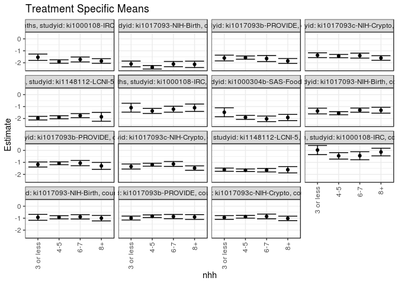

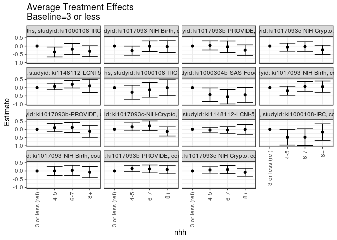

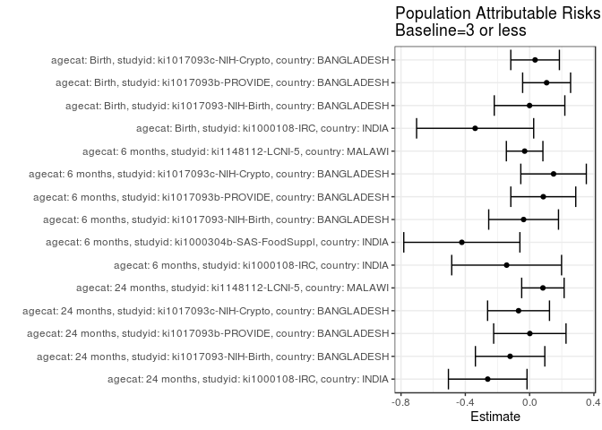

## Results Table

### Parameter: TSM

| agecat | studyid | country | intervention_level | baseline_level | estimate | ci_lower | ci_upper |
| --- | --- | --- | --- | --- | --- | --- | --- |
| Birth | ki1000108-IRC | INDIA | 3 or less | NA | 0.0308064 | -0.3516943 | 0.4133071 |
| Birth | ki1000108-IRC | INDIA | 4-5 | NA | -0.4557190 | -0.7242950 | -0.1871429 |
| Birth | ki1000108-IRC | INDIA | 6-7 | NA | -0.4441713 | -0.7782395 | -0.1101032 |
| Birth | ki1000108-IRC | INDIA | 8+ | NA | -0.1365393 | -0.4550364 | 0.1819578 |
| Birth | ki1017093-NIH-Birth | BANGLADESH | 3 or less | NA | -0.9306835 | -1.1765765 | -0.6847904 |
| Birth | ki1017093-NIH-Birth | BANGLADESH | 4-5 | NA | -0.9268742 | -1.0613101 | -0.7924383 |
| Birth | ki1017093-NIH-Birth | BANGLADESH | 6-7 | NA | -0.8904707 | -1.0728398 | -0.7081015 |
| Birth | ki1017093-NIH-Birth | BANGLADESH | 8+ | NA | -1.0022272 | -1.2308966 | -0.7735577 |
| Birth | ki1017093b-PROVIDE | BANGLADESH | 3 or less | NA | -0.9909345 | -1.1528734 | -0.8289955 |
| Birth | ki1017093b-PROVIDE | BANGLADESH | 4-5 | NA | -0.8398666 | -0.9501400 | -0.7295932 |
| Birth | ki1017093b-PROVIDE | BANGLADESH | 6-7 | NA | -0.8666212 | -1.0432243 | -0.6900181 |
| Birth | ki1017093b-PROVIDE | BANGLADESH | 8+ | NA | -0.9035602 | -1.1047183 | -0.7024021 |
| Birth | ki1017093c-NIH-Crypto | BANGLADESH | 3 or less | NA | -0.9436556 | -1.0986976 | -0.7886135 |
| Birth | ki1017093c-NIH-Crypto | BANGLADESH | 4-5 | NA | -0.8819721 | -0.9945902 | -0.7693541 |
| Birth | ki1017093c-NIH-Crypto | BANGLADESH | 6-7 | NA | -0.8558894 | -1.0535850 | -0.6581937 |
| Birth | ki1017093c-NIH-Crypto | BANGLADESH | 8+ | NA | -1.0193830 | -1.2042892 | -0.8344767 |
| 6 months | ki1000108-IRC | INDIA | 3 or less | NA | -1.0915718 | -1.4619176 | -0.7212259 |
| 6 months | ki1000108-IRC | INDIA | 4-5 | NA | -1.3649144 | -1.5751864 | -1.1546423 |
| 6 months | ki1000108-IRC | INDIA | 6-7 | NA | -1.2181575 | -1.4663308 | -0.9699841 |
| 6 months | ki1000108-IRC | INDIA | 8+ | NA | -1.0952273 | -1.4049723 | -0.7854823 |
| 6 months | ki1000304b-SAS-FoodSuppl | INDIA | 3 or less | NA | -1.4770197 | -1.8498649 | -1.1041745 |
| 6 months | ki1000304b-SAS-FoodSuppl | INDIA | 4-5 | NA | -1.9016898 | -2.0682738 | -1.7351059 |
| 6 months | ki1000304b-SAS-FoodSuppl | INDIA | 6-7 | NA | -2.0244924 | -2.2567349 | -1.7922500 |
| 6 months | ki1000304b-SAS-FoodSuppl | INDIA | 8+ | NA | -1.9116462 | -2.1698657 | -1.6534267 |
| 6 months | ki1017093-NIH-Birth | BANGLADESH | 3 or less | NA | -1.3700538 | -1.6099504 | -1.1301572 |
| 6 months | ki1017093-NIH-Birth | BANGLADESH | 4-5 | NA | -1.5526219 | -1.6843346 | -1.4209092 |
| 6 months | ki1017093-NIH-Birth | BANGLADESH | 6-7 | NA | -1.2943931 | -1.4673912 | -1.1213949 |
| 6 months | ki1017093-NIH-Birth | BANGLADESH | 8+ | NA | -1.3062130 | -1.5513095 | -1.0611165 |
| 6 months | ki1017093b-PROVIDE | BANGLADESH | 3 or less | NA | -1.1768769 | -1.3901992 | -0.9635545 |
| 6 months | ki1017093b-PROVIDE | BANGLADESH | 4-5 | NA | -1.0761196 | -1.1978957 | -0.9543435 |
| 6 months | ki1017093b-PROVIDE | BANGLADESH | 6-7 | NA | -1.0612238 | -1.2799609 | -0.8424868 |
| 6 months | ki1017093b-PROVIDE | BANGLADESH | 8+ | NA | -1.2955356 | -1.5884108 | -1.0026604 |
| 6 months | ki1017093c-NIH-Crypto | BANGLADESH | 3 or less | NA | -1.3477498 | -1.5574103 | -1.1380894 |
| 6 months | ki1017093c-NIH-Crypto | BANGLADESH | 4-5 | NA | -1.1957032 | -1.3153994 | -1.0760070 |
| 6 months | ki1017093c-NIH-Crypto | BANGLADESH | 6-7 | NA | -1.1341795 | -1.3407323 | -0.9276267 |
| 6 months | ki1017093c-NIH-Crypto | BANGLADESH | 8+ | NA | -1.4755743 | -1.6578956 | -1.2932530 |
| 6 months | ki1148112-LCNI-5 | MALAWI | 3 or less | NA | -1.6117763 | -1.7466010 | -1.4769516 |
| 6 months | ki1148112-LCNI-5 | MALAWI | 4-5 | NA | -1.6545722 | -1.7591643 | -1.5499801 |
| 6 months | ki1148112-LCNI-5 | MALAWI | 6-7 | NA | -1.6520157 | -1.7981872 | -1.5058442 |
| 6 months | ki1148112-LCNI-5 | MALAWI | 8+ | NA | -1.6156318 | -1.8790199 | -1.3522438 |
| 24 months | ki1000108-IRC | INDIA | 3 or less | NA | -1.5382462 | -1.8029179 | -1.2735745 |
| 24 months | ki1000108-IRC | INDIA | 4-5 | NA | -1.8979033 | -2.0411070 | -1.7546996 |
| 24 months | ki1000108-IRC | INDIA | 6-7 | NA | -1.7249765 | -1.9291065 | -1.5208465 |
| 24 months | ki1000108-IRC | INDIA | 8+ | NA | -1.8525023 | -2.0477034 | -1.6573012 |
| 24 months | ki1017093-NIH-Birth | BANGLADESH | 3 or less | NA | -2.0978017 | -2.3352880 | -1.8603154 |
| 24 months | ki1017093-NIH-Birth | BANGLADESH | 4-5 | NA | -2.3758667 | -2.5213721 | -2.2303614 |
| 24 months | ki1017093-NIH-Birth | BANGLADESH | 6-7 | NA | -2.1080252 | -2.3278423 | -1.8882081 |
| 24 months | ki1017093-NIH-Birth | BANGLADESH | 8+ | NA | -2.1321789 | -2.3972401 | -1.8671176 |
| 24 months | ki1017093b-PROVIDE | BANGLADESH | 3 or less | NA | -1.6038957 | -1.8437722 | -1.3640193 |
| 24 months | ki1017093b-PROVIDE | BANGLADESH | 4-5 | NA | -1.5676951 | -1.7037880 | -1.4316022 |
| 24 months | ki1017093b-PROVIDE | BANGLADESH | 6-7 | NA | -1.6467561 | -1.9005681 | -1.3929442 |
| 24 months | ki1017093b-PROVIDE | BANGLADESH | 8+ | NA | -1.8508658 | -2.0575389 | -1.6441927 |
| 24 months | ki1017093c-NIH-Crypto | BANGLADESH | 3 or less | NA | -1.3724286 | -1.5723958 | -1.1724614 |
| 24 months | ki1017093c-NIH-Crypto | BANGLADESH | 4-5 | NA | -1.4400371 | -1.5779802 | -1.3020940 |
| 24 months | ki1017093c-NIH-Crypto | BANGLADESH | 6-7 | NA | -1.4026470 | -1.6109245 | -1.1943695 |
| 24 months | ki1017093c-NIH-Crypto | BANGLADESH | 8+ | NA | -1.6006430 | -1.7925555 | -1.4087305 |
| 24 months | ki1148112-LCNI-5 | MALAWI | 3 or less | NA | -1.9650450 | -2.1167668 | -1.8133232 |
| 24 months | ki1148112-LCNI-5 | MALAWI | 4-5 | NA | -1.8904999 | -2.0173589 | -1.7636409 |
| 24 months | ki1148112-LCNI-5 | MALAWI | 6-7 | NA | -1.7558243 | -1.9249922 | -1.5866564 |
| 24 months | ki1148112-LCNI-5 | MALAWI | 8+ | NA | -1.8535729 | -2.2228426 | -1.4843033 |

### Parameter: E(Y)

| agecat | studyid | country | intervention_level | baseline_level | estimate | ci_lower | ci_upper |
| --- | --- | --- | --- | --- | --- | --- | --- |
| Birth | ki1000108-IRC | INDIA | NA | NA | -0.3080412 | -0.4687931 | -0.1472894 |
| Birth | ki1017093-NIH-Birth | BANGLADESH | NA | NA | -0.9310197 | -1.0197391 | -0.8423003 |
| Birth | ki1017093b-PROVIDE | BANGLADESH | NA | NA | -0.8851020 | -0.9601332 | -0.8100709 |
| Birth | ki1017093c-NIH-Crypto | BANGLADESH | NA | NA | -0.9094945 | -0.9809370 | -0.8380521 |
| 6 months | ki1000108-IRC | INDIA | NA | NA | -1.2344062 | -1.3658524 | -1.1029600 |
| 6 months | ki1000304b-SAS-FoodSuppl | INDIA | NA | NA | -1.8986842 | -2.0118892 | -1.7854792 |
| 6 months | ki1017093-NIH-Birth | BANGLADESH | NA | NA | -1.4073821 | -1.4960598 | -1.3187043 |
| 6 months | ki1017093b-PROVIDE | BANGLADESH | NA | NA | -1.0916915 | -1.1661176 | -1.0172654 |
| 6 months | ki1017093c-NIH-Crypto | BANGLADESH | NA | NA | -1.1986783 | -1.2700937 | -1.1272630 |
| 6 months | ki1148112-LCNI-5 | MALAWI | NA | NA | -1.6426961 | -1.7120603 | -1.5733318 |
| 24 months | ki1000108-IRC | INDIA | NA | NA | -1.7987775 | -1.8923914 | -1.7051636 |
| 24 months | ki1017093-NIH-Birth | BANGLADESH | NA | NA | -2.2190579 | -2.3217459 | -2.1163699 |
| 24 months | ki1017093b-PROVIDE | BANGLADESH | NA | NA | -1.6024221 | -1.6857420 | -1.5191023 |
| 24 months | ki1017093c-NIH-Crypto | BANGLADESH | NA | NA | -1.4412646 | -1.5249156 | -1.3576135 |
| 24 months | ki1148112-LCNI-5 | MALAWI | NA | NA | -1.8822648 | -1.9637218 | -1.8008078 |

### Parameter: ATE

| agecat | studyid | country | intervention_level | baseline_level | estimate | ci_lower | ci_upper |
| --- | --- | --- | --- | --- | --- | --- | --- |
| Birth | ki1000108-IRC | INDIA | 3 or less | 3 or less | 0.0000000 | 0.0000000 | 0.0000000 |
| Birth | ki1000108-IRC | INDIA | 4-5 | 3 or less | -0.4865254 | -0.9537211 | -0.0193297 |
| Birth | ki1000108-IRC | INDIA | 6-7 | 3 or less | -0.4749778 | -0.9831500 | 0.0331945 |
| Birth | ki1000108-IRC | INDIA | 8+ | 3 or less | -0.1673457 | -0.6660632 | 0.3313718 |
| Birth | ki1017093-NIH-Birth | BANGLADESH | 3 or less | 3 or less | 0.0000000 | 0.0000000 | 0.0000000 |
| Birth | ki1017093-NIH-Birth | BANGLADESH | 4-5 | 3 or less | 0.0038093 | -0.2755887 | 0.2832073 |
| Birth | ki1017093-NIH-Birth | BANGLADESH | 6-7 | 3 or less | 0.0402128 | -0.2644947 | 0.3449203 |
| Birth | ki1017093-NIH-Birth | BANGLADESH | 8+ | 3 or less | -0.0715437 | -0.4089415 | 0.2658541 |
| Birth | ki1017093b-PROVIDE | BANGLADESH | 3 or less | 3 or less | 0.0000000 | 0.0000000 | 0.0000000 |
| Birth | ki1017093b-PROVIDE | BANGLADESH | 4-5 | 3 or less | 0.1510679 | -0.0441224 | 0.3462581 |
| Birth | ki1017093b-PROVIDE | BANGLADESH | 6-7 | 3 or less | 0.1243132 | -0.1146812 | 0.3633076 |
| Birth | ki1017093b-PROVIDE | BANGLADESH | 8+ | 3 or less | 0.0873742 | -0.1704336 | 0.3451821 |
| Birth | ki1017093c-NIH-Crypto | BANGLADESH | 3 or less | 3 or less | 0.0000000 | 0.0000000 | 0.0000000 |
| Birth | ki1017093c-NIH-Crypto | BANGLADESH | 4-5 | 3 or less | 0.0616834 | -0.1295923 | 0.2529591 |
| Birth | ki1017093c-NIH-Crypto | BANGLADESH | 6-7 | 3 or less | 0.0877662 | -0.1632119 | 0.3387443 |
| Birth | ki1017093c-NIH-Crypto | BANGLADESH | 8+ | 3 or less | -0.0757274 | -0.3165742 | 0.1651194 |
| 6 months | ki1000108-IRC | INDIA | 3 or less | 3 or less | 0.0000000 | 0.0000000 | 0.0000000 |
| 6 months | ki1000108-IRC | INDIA | 4-5 | 3 or less | -0.2733426 | -0.6992510 | 0.1525659 |
| 6 months | ki1000108-IRC | INDIA | 6-7 | 3 or less | -0.1265857 | -0.5722910 | 0.3191196 |
| 6 months | ki1000108-IRC | INDIA | 8+ | 3 or less | -0.0036555 | -0.4863767 | 0.4790657 |
| 6 months | ki1000304b-SAS-FoodSuppl | INDIA | 3 or less | 3 or less | 0.0000000 | 0.0000000 | 0.0000000 |
| 6 months | ki1000304b-SAS-FoodSuppl | INDIA | 4-5 | 3 or less | -0.4246702 | -0.8328408 | -0.0164995 |
| 6 months | ki1000304b-SAS-FoodSuppl | INDIA | 6-7 | 3 or less | -0.5474727 | -0.9863702 | -0.1085753 |
| 6 months | ki1000304b-SAS-FoodSuppl | INDIA | 8+ | 3 or less | -0.4346265 | -0.8878491 | 0.0185961 |
| 6 months | ki1017093-NIH-Birth | BANGLADESH | 3 or less | 3 or less | 0.0000000 | 0.0000000 | 0.0000000 |
| 6 months | ki1017093-NIH-Birth | BANGLADESH | 4-5 | 3 or less | -0.1825681 | -0.4551206 | 0.0899844 |
| 6 months | ki1017093-NIH-Birth | BANGLADESH | 6-7 | 3 or less | 0.0756608 | -0.2181868 | 0.3695083 |
| 6 months | ki1017093-NIH-Birth | BANGLADESH | 8+ | 3 or less | 0.0638408 | -0.2778828 | 0.4055643 |
| 6 months | ki1017093b-PROVIDE | BANGLADESH | 3 or less | 3 or less | 0.0000000 | 0.0000000 | 0.0000000 |
| 6 months | ki1017093b-PROVIDE | BANGLADESH | 4-5 | 3 or less | 0.1007572 | -0.1451572 | 0.3466716 |
| 6 months | ki1017093b-PROVIDE | BANGLADESH | 6-7 | 3 or less | 0.1156530 | -0.1895720 | 0.4208780 |
| 6 months | ki1017093b-PROVIDE | BANGLADESH | 8+ | 3 or less | -0.1186587 | -0.4808611 | 0.2435437 |
| 6 months | ki1017093c-NIH-Crypto | BANGLADESH | 3 or less | 3 or less | 0.0000000 | 0.0000000 | 0.0000000 |
| 6 months | ki1017093c-NIH-Crypto | BANGLADESH | 4-5 | 3 or less | 0.1520467 | -0.0896238 | 0.3937171 |
| 6 months | ki1017093c-NIH-Crypto | BANGLADESH | 6-7 | 3 or less | 0.2135703 | -0.0811794 | 0.5083200 |
| 6 months | ki1017093c-NIH-Crypto | BANGLADESH | 8+ | 3 or less | -0.1278244 | -0.4059697 | 0.1503208 |
| 6 months | ki1148112-LCNI-5 | MALAWI | 3 or less | 3 or less | 0.0000000 | 0.0000000 | 0.0000000 |
| 6 months | ki1148112-LCNI-5 | MALAWI | 4-5 | 3 or less | -0.0427959 | -0.2120154 | 0.1264236 |
| 6 months | ki1148112-LCNI-5 | MALAWI | 6-7 | 3 or less | -0.0402394 | -0.2378667 | 0.1573880 |
| 6 months | ki1148112-LCNI-5 | MALAWI | 8+ | 3 or less | -0.0038555 | -0.2976146 | 0.2899036 |
| 24 months | ki1000108-IRC | INDIA | 3 or less | 3 or less | 0.0000000 | 0.0000000 | 0.0000000 |
| 24 months | ki1000108-IRC | INDIA | 4-5 | 3 or less | -0.3596571 | -0.6605675 | -0.0587468 |
| 24 months | ki1000108-IRC | INDIA | 6-7 | 3 or less | -0.1867303 | -0.5212582 | 0.1477976 |
| 24 months | ki1000108-IRC | INDIA | 8+ | 3 or less | -0.3142561 | -0.6431802 | 0.0146681 |
| 24 months | ki1017093-NIH-Birth | BANGLADESH | 3 or less | 3 or less | 0.0000000 | 0.0000000 | 0.0000000 |
| 24 months | ki1017093-NIH-Birth | BANGLADESH | 4-5 | 3 or less | -0.2780650 | -0.5548605 | -0.0012696 |
| 24 months | ki1017093-NIH-Birth | BANGLADESH | 6-7 | 3 or less | -0.0102235 | -0.3312535 | 0.3108064 |
| 24 months | ki1017093-NIH-Birth | BANGLADESH | 8+ | 3 or less | -0.0343772 | -0.3883953 | 0.3196409 |
| 24 months | ki1017093b-PROVIDE | BANGLADESH | 3 or less | 3 or less | 0.0000000 | 0.0000000 | 0.0000000 |
| 24 months | ki1017093b-PROVIDE | BANGLADESH | 4-5 | 3 or less | 0.0362006 | -0.2392846 | 0.3116859 |
| 24 months | ki1017093b-PROVIDE | BANGLADESH | 6-7 | 3 or less | -0.0428604 | -0.3918817 | 0.3061609 |
| 24 months | ki1017093b-PROVIDE | BANGLADESH | 8+ | 3 or less | -0.2469700 | -0.5630182 | 0.0690781 |
| 24 months | ki1017093c-NIH-Crypto | BANGLADESH | 3 or less | 3 or less | 0.0000000 | 0.0000000 | 0.0000000 |
| 24 months | ki1017093c-NIH-Crypto | BANGLADESH | 4-5 | 3 or less | -0.0676085 | -0.3095154 | 0.1742985 |
| 24 months | ki1017093c-NIH-Crypto | BANGLADESH | 6-7 | 3 or less | -0.0302184 | -0.3180958 | 0.2576590 |
| 24 months | ki1017093c-NIH-Crypto | BANGLADESH | 8+ | 3 or less | -0.2282144 | -0.5043820 | 0.0479532 |
| 24 months | ki1148112-LCNI-5 | MALAWI | 3 or less | 3 or less | 0.0000000 | 0.0000000 | 0.0000000 |
| 24 months | ki1148112-LCNI-5 | MALAWI | 4-5 | 3 or less | 0.0745451 | -0.1234479 | 0.2725381 |
| 24 months | ki1148112-LCNI-5 | MALAWI | 6-7 | 3 or less | 0.2092207 | -0.0179511 | 0.4363926 |
| 24 months | ki1148112-LCNI-5 | MALAWI | 8+ | 3 or less | 0.1114721 | -0.2877422 | 0.5106863 |

### Parameter: PAR

| agecat | studyid | country | intervention_level | baseline_level | estimate | ci_lower | ci_upper |
| --- | --- | --- | --- | --- | --- | --- | --- |
| Birth | ki1000108-IRC | INDIA | 3 or less | NA | -0.3388477 | -0.7031212 | 0.0254259 |
| Birth | ki1017093-NIH-Birth | BANGLADESH | 3 or less | NA | -0.0003363 | -0.2198932 | 0.2192207 |
| Birth | ki1017093b-PROVIDE | BANGLADESH | 3 or less | NA | 0.1058324 | -0.0433667 | 0.2550315 |
| Birth | ki1017093c-NIH-Crypto | BANGLADESH | 3 or less | NA | 0.0341610 | -0.1170582 | 0.1853802 |
| 6 months | ki1000108-IRC | INDIA | 3 or less | NA | -0.1428344 | -0.4845333 | 0.1988645 |
| 6 months | ki1000304b-SAS-FoodSuppl | INDIA | 3 or less | NA | -0.4216645 | -0.7829050 | -0.0604240 |
| 6 months | ki1017093-NIH-Birth | BANGLADESH | 3 or less | NA | -0.0373282 | -0.2544180 | 0.1797616 |
| 6 months | ki1017093b-PROVIDE | BANGLADESH | 3 or less | NA | 0.0851854 | -0.1167935 | 0.2871642 |
| 6 months | ki1017093c-NIH-Crypto | BANGLADESH | 3 or less | NA | 0.1490715 | -0.0547678 | 0.3529109 |
| 6 months | ki1148112-LCNI-5 | MALAWI | 3 or less | NA | -0.0309198 | -0.1446220 | 0.0827824 |
| 24 months | ki1000108-IRC | INDIA | 3 or less | NA | -0.2605313 | -0.5050632 | -0.0159994 |
| 24 months | ki1017093-NIH-Birth | BANGLADESH | 3 or less | NA | -0.1212562 | -0.3372294 | 0.0947170 |
| 24 months | ki1017093b-PROVIDE | BANGLADESH | 3 or less | NA | 0.0014736 | -0.2236264 | 0.2265736 |
| 24 months | ki1017093c-NIH-Crypto | BANGLADESH | 3 or less | NA | -0.0688360 | -0.2613730 | 0.1237011 |
| 24 months | ki1148112-LCNI-5 | MALAWI | 3 or less | NA | 0.0827802 | -0.0492614 | 0.2148217 |